# Ensemble_Travel_Package_Purchase_Prediction_Ong_Min_Hau

#### ProdTaken vs Designation:

```
ProdTaken          0    1   All
Designation
AVP              322   20   342
Executive       1290  552  1842
Manager         1528  204  1732
Senior Manager   618  124   742
VP               210   20   230
All             3968  920  4888
--------------------------------------------------------------------------------------------------------------
```

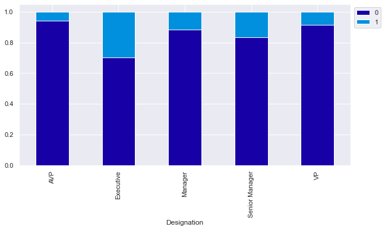

```python
stacked_plot(data["Designation"])
```

- Approx 30% of customers who are Executive purchased a travel package, and this percentage is signigicantly larger than any other categories of designation.
- Customers who are Senior Manager showed the second largest percentage of them purchased a package, which was approx 16.7%.
- Less than 10% of VP and AVP purchased a travel package.

#### ProdTaken vs PreferredPropertyStar:

```
ProdTaken                 0    1   All
PreferredPropertyStar
3.0                    2511  482  2993
4.0                     731  182   913
5.0                     706  250   956
All                    3948  914  4862
--------------------------------------------------------------------------------------------------------------
```

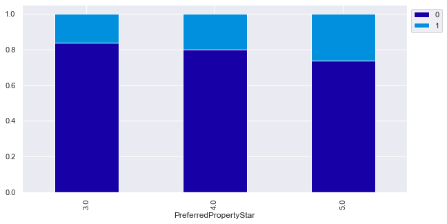

```python
stacked_plot(data["PreferredPropertyStar"])
```

- Approx 26.15% of customers whose PreferPropertyStar is 5 ended up did purchase a travel package.
- Less than 20% of customers whose PreferPropertyStar is either 3 or 4 did purchase a travel package.

#### ProdTaken vs PitchSatisfactionScore:

```
ProdTaken                  0    1   All
PitchSatisfactionScore
1                        798  144   942
2                        498   88   586
3                       1162  316  1478
4                        750  162   912
5                        760  210   970
All                     3968  920  4888
--------------------------------------------------------------------------------------------------------------
```

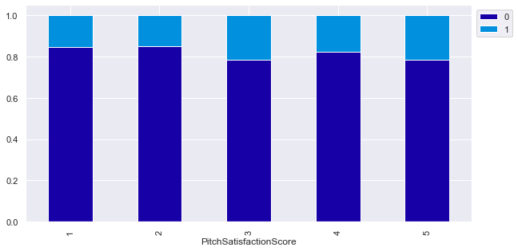

```python
stacked_plot(data["PitchSatisfactionScore"])
```

- Expectedly salespersons whose PitchSatisfactionScore is 3-5 closed largest percentage of deals.
- However, salespersons whose PitchSatisfactionScore is 3 actually tend to be able to close a deal than those whose PitchSatisfactionScore is 4.

#### ProdTaken vs NumberOfFollowups:

```
ProdTaken             0    1   All
NumberOfFollowups
1.0                 156   20   176
2.0                 205   24   229
3.0                1222  244  1466
4.0                1689  379  2068
5.0                 577  191   768
6.0                  82   54   136
All                3931  912  4843
--------------------------------------------------------------------------------------------------------------
```

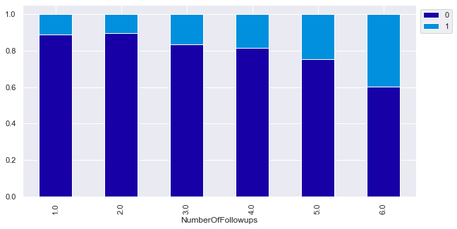

```python
stacked_plot(data["NumberOfFollowups"])
```

- A customer tend to purchase a travel package if there were more follow-ups done by a salesperson.
- Approx 39.7% of customers who experienced 6 times of follow-ups did purchase a package.

#### ProdTaken vs ProductPitched:

```
ProdTaken          0    1   All
ProductPitched
Basic           1290  552  1842
Standard         618  124   742
Deluxe          1528  204  1732
Super Deluxe     322   20   342
King             210   20   230
All             3968  920  4888
--------------------------------------------------------------------------------------------------------------
```

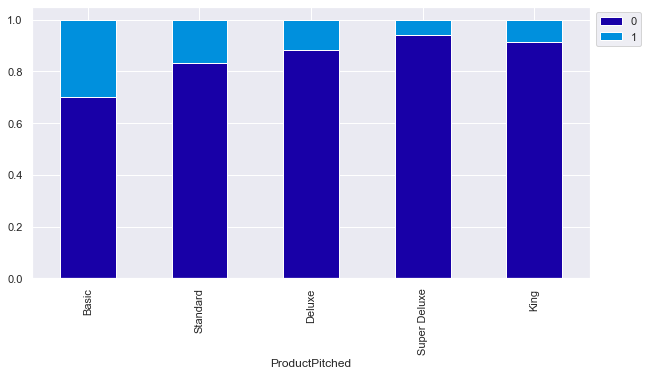

```python
stacked_plot(data["ProductPitched"])
```

#### A different view of ProdTaken vs ProductPitched:

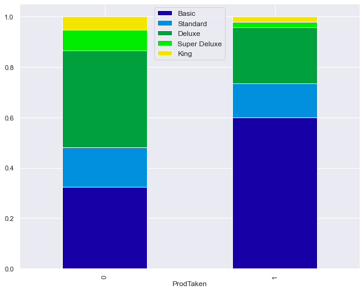

```python
sns.set(palette="nipy_spectral")
pd.crosstab(data['ProdTaken'],data['ProductPitched'], normalize="index"
           ).plot(kind="bar",stacked=True, figsize=(10, 8))
plt.legend(loc="upper center",  prop={"size":12})
plt.show()
```

- The stacked chart above shows that, among all the customers who purchased a travel package, most of them purchased Basic Pacakge but the second most popular package is Deluxe Package, then only followed by Standard Package.
- From our dataset we have approx 35.4% of customers being pitched for Deluxe Package, compared with only 15.2% of them being pitched for Standard Package.
- One factor we could derive from the incident above is that: **salespersons have been putting more effort in pitching Deluxe Package** rather than Standard Package, which **resulted in having more Deluxed Package being sold despite lower closure rate than Standard Package.**

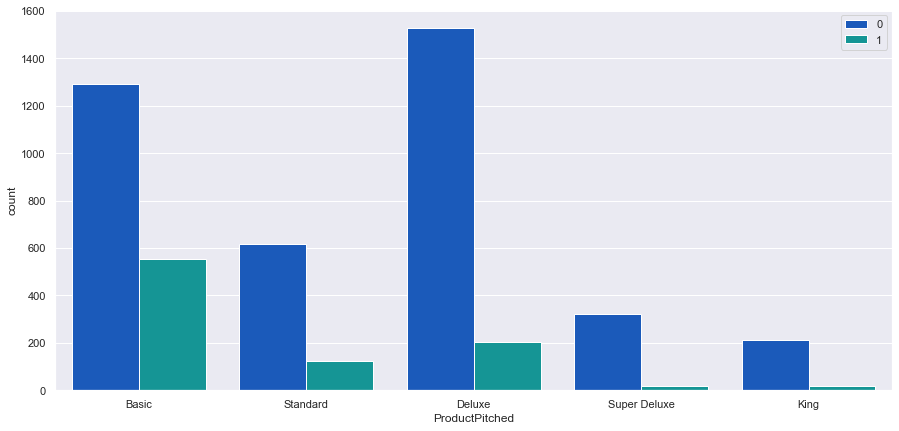

```python
plt.figure(figsize=(15,7))
sns.countplot(data['ProductPitched'],hue=data['ProdTaken'],palette='winter')
plt.legend(bbox_to_anchor=(1.00, 1))
plt.show()
```

- The countplot above shows a different view of previous stacked chart in terms of number of different packages purchased by customers.
- We could see that salespersons have been pitching Deluxe products the most indeed, which further justified our earlier observation.

## 3.3) Customer profile (characteristics of a customer) of the different packages

Before we build the customer profile, let's take a look at which CityTier the customers mainly come from for different travel packages:

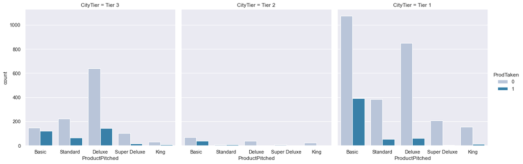

```python
sns.catplot(x='ProductPitched',col='CityTier', hue='ProdTaken',
            data=data,kind='count', palette='PuBu');
```

- We are interested in customers who actually puchased a package.
- One observation we may derive from the catplot above is that, most customers who purchased Basic package is from Tier-1 city.

#### Basic package:

```python
data[data['ProductPitched']=='Basic'][data['ProdTaken']==1].describe().T
```

|  | count | mean | std | min | 25% | 50% | 75% | max |
| --- | --- | --- | --- | --- | --- | --- | --- | --- |
| Age | 515.0 | 31.289320 | 9.070829 | 18.0 | 25.0 | 30.0 | 35.0 | 59.0 |
| DurationOfPitch | 532.0 | 15.791353 | 7.906926 | 6.0 | 9.0 | 14.0 | 22.0 | 36.0 |
| NumberOfPersonVisiting | 552.0 | 2.905797 | 0.701439 | 2.0 | 2.0 | 3.0 | 3.0 | 4.0 |
| NumberOfFollowups | 548.0 | 3.950730 | 0.967166 | 1.0 | 3.0 | 4.0 | 5.0 | 6.0 |
| PreferredPropertyStar | 552.0 | 3.771739 | 0.861812 | 3.0 | 3.0 | 3.0 | 5.0 | 5.0 |
| NumberOfTrips | 547.0 | 3.226691 | 2.081618 | 1.0 | 2.0 | 3.0 | 4.0 | 20.0 |
| PitchSatisfactionScore | 552.0 | 3.213768 | 1.353074 | 1.0 | 2.0 | 3.0 | 4.0 | 5.0 |
| NumberOfChildrenVisiting | 551.0 | 1.221416 | 0.866537 | 0.0 | 1.0 | 1.0 | 2.0 | 3.0 |
| MonthlyIncome | 529.0 | 20161.529301 | 3313.289684 | 16009.0 | 17546.0 | 20582.0 | 21394.0 | 37868.0 |

```python
data[data['ProductPitched']=='Basic'][data['ProdTaken']==1].describe(include='category').T
```

|  | count | unique | top | freq |
| --- | --- | --- | --- | --- |
| ProdTaken | 552 | 1 | 1 | 552 |
| TypeofContact | 549 | 2 | Self Enquiry | 355 |
| CityTier | 552 | 3 | Tier 1 | 392 |
| Occupation | 552 | 3 | Salaried | 260 |
| Gender | 552 | 2 | Male | 344 |
| ProductPitched | 552 | 1 | Basic | 552 |
| MaritalStatus | 552 | 4 | Single | 230 |
| Passport | 552 | 2 | 1 | 322 |
| OwnCar | 552 | 2 | 1 | 316 |
| Designation | 552 | 1 | Executive | 552 |

**Most customers purchased Basic package and those who purchased this package were all executives.**

- Below is a general profile of majority of customers who purchased Basic package:
  - 25 to 35 years old
  - working as an executive
  - monthly income 17K to 22K
  - salaried employee
  - From Tier-1 city
  - Single
  - Has a passport
  - own a car
  - travel 3 times a year on average

#### Standard Package:

```python
data[data['ProductPitched']=='Standard'][data['ProdTaken']==1].describe().T
```

|  | count | mean | std | min | 25% | 50% | 75% | max |
| --- | --- | --- | --- | --- | --- | --- | --- | --- |
| Age | 123.0 | 41.008130 | 9.876695 | 19.0 | 33.00 | 38.0 | 49.00 | 60.0 |
| DurationOfPitch | 123.0 | 19.065041 | 9.048811 | 6.0 | 11.00 | 17.0 | 29.00 | 36.0 |
| NumberOfPersonVisiting | 124.0 | 2.967742 | 0.709236 | 2.0 | 2.00 | 3.0 | 3.00 | 4.0 |
| NumberOfFollowups | 124.0 | 3.935484 | 0.908335 | 1.0 | 3.00 | 4.0 | 4.25 | 6.0 |
| PreferredPropertyStar | 123.0 | 3.731707 | 0.878460 | 3.0 | 3.00 | 3.0 | 5.00 | 5.0 |
| NumberOfTrips | 123.0 | 3.016260 | 1.815163 | 1.0 | 2.00 | 2.0 | 4.00 | 8.0 |
| PitchSatisfactionScore | 124.0 | 3.467742 | 1.309350 | 1.0 | 3.00 | 3.0 | 5.00 | 5.0 |
| NumberOfChildrenVisiting | 123.0 | 1.121951 | 0.901596 | 0.0 | 0.00 | 1.0 | 2.00 | 3.0 |
| MonthlyIncome | 124.0 | 26035.419355 | 3593.290353 | 17372.0 | 23974.75 | 25711.0 | 28628.00 | 38395.0 |

```python
data[data['ProductPitched']=='Standard'][data['ProdTaken']==1].describe(include='category').T
```

|  | count | unique | top | freq |
| --- | --- | --- | --- | --- |
| ProdTaken | 124 | 1 | 1 | 124 |
| TypeofContact | 124 | 2 | Self Enquiry | 92 |
| CityTier | 124 | 3 | Tier 3 | 64 |
| Occupation | 124 | 3 | Small Business | 58 |
| Gender | 124 | 2 | Male | 76 |
| ProductPitched | 124 | 1 | Standard | 124 |
| MaritalStatus | 124 | 4 | Married | 56 |
| Passport | 124 | 2 | 0 | 76 |
| OwnCar | 124 | 2 | 1 | 82 |
| Designation | 124 | 1 | Senior Manager | 124 |

**Standard package form the 3rd largest group of customers and those customers are senior managers.**

- Below is a general profile of majority of customers who purchased Standard package:
  - 33 to 49 years old
  - working as a senior manager
  - monthly income 23K to 29K
  - Small business
  - Either from Tier-1 or Tier-3 city
  - own a car
  - travel twice a year on average

#### Deluxe Package:

```python
data[data['ProductPitched']=='Deluxe'][data['ProdTaken']==1].describe().T
```

|  | count | mean | std | min | 25% | 50% | 75% | max |
| --- | --- | --- | --- | --- | --- | --- | --- | --- |
| Age | 198.0 | 37.641414 | 8.469575 | 21.0 | 32.0 | 35.5 | 44.0 | 59.0 |
| DurationOfPitch | 180.0 | 19.100000 | 9.227176 | 6.0 | 11.0 | 16.0 | 28.0 | 36.0 |
| NumberOfPersonVisiting | 204.0 | 2.950980 | 0.707141 | 2.0 | 2.0 | 3.0 | 3.0 | 4.0 |
| NumberOfFollowups | 200.0 | 3.970000 | 1.051011 | 1.0 | 3.0 | 4.0 | 5.0 | 6.0 |
| PreferredPropertyStar | 203.0 | 3.699507 | 0.857899 | 3.0 | 3.0 | 3.0 | 5.0 | 5.0 |
| NumberOfTrips | 202.0 | 3.702970 | 2.022483 | 1.0 | 2.0 | 3.0 | 5.0 | 8.0 |
| PitchSatisfactionScore | 204.0 | 3.039216 | 1.278250 | 1.0 | 2.0 | 3.0 | 4.0 | 5.0 |
| NumberOfChildrenVisiting | 203.0 | 1.172414 | 0.841279 | 0.0 | 1.0 | 1.0 | 2.0 | 3.0 |
| MonthlyIncome | 195.0 | 23106.215385 | 3592.466947 | 17086.0 | 20744.0 | 23186.0 | 24506.0 | 38525.0 |

```python
data[data['ProductPitched']=='Deluxe'][data['ProdTaken']==1].describe(include='category').T
```

|  | count | unique | top | freq |
| --- | --- | --- | --- | --- |
| ProdTaken | 204 | 1 | 1 | 204 |
| TypeofContact | 204 | 2 | Self Enquiry | 136 |
| CityTier | 204 | 2 | Tier 3 | 144 |
| Occupation | 204 | 3 | Small Business | 108 |
| Gender | 204 | 2 | Male | 134 |
| ProductPitched | 204 | 1 | Deluxe | 204 |
| MaritalStatus | 204 | 4 | Married | 68 |
| Passport | 204 | 2 | 0 | 104 |
| OwnCar | 204 | 2 | 1 | 124 |
| Designation | 204 | 1 | Manager | 204 |

**Deluxe package is the second most popular product and being purchased by customers who are a manager.**

- Below is a general profile of majority of customers who purchased Deluxe package:
  - 30 to 45 years old
  - working as a manager
  - monthly income 20K to 25K
  - Small business
  - From Tier-3 city
  - own a car
  - travel three times a year on average

#### Super Deluxe Package:

```python
data[data['ProductPitched']=='Super Deluxe'][data['ProdTaken']==1].describe().T
```

|  | count | mean | std | min | 25% | 50% | 75% | max |
| --- | --- | --- | --- | --- | --- | --- | --- | --- |
| Age | 20.0 | 43.500000 | 4.839530 | 39.0 | 40.0 | 42.0 | 45.25 | 56.0 |
| DurationOfPitch | 20.0 | 18.500000 | 7.330542 | 8.0 | 15.0 | 18.5 | 20.00 | 31.0 |
| NumberOfPersonVisiting | 20.0 | 2.700000 | 0.656947 | 2.0 | 2.0 | 3.0 | 3.00 | 4.0 |
| NumberOfFollowups | 20.0 | 3.100000 | 1.618967 | 1.0 | 2.0 | 3.0 | 4.00 | 6.0 |
| PreferredPropertyStar | 20.0 | 3.600000 | 0.820783 | 3.0 | 3.0 | 3.0 | 4.00 | 5.0 |
| NumberOfTrips | 19.0 | 3.263158 | 2.490919 | 1.0 | 1.0 | 2.0 | 5.50 | 8.0 |
| PitchSatisfactionScore | 20.0 | 3.800000 | 1.005249 | 3.0 | 3.0 | 3.0 | 5.00 | 5.0 |
| NumberOfChildrenVisiting | 20.0 | 1.200000 | 0.833509 | 0.0 | 1.0 | 1.0 | 2.00 | 3.0 |
| MonthlyIncome | 20.0 | 29823.800000 | 3520.426404 | 21151.0 | 28129.5 | 29802.5 | 31997.25 | 37502.0 |

```python
data[data['ProductPitched']=='Super Deluxe'][data['ProdTaken']==1].describe(include='category').T
```

|  | count | unique | top | freq |
| --- | --- | --- | --- | --- |
| ProdTaken | 20 | 1 | 1 | 20 |
| TypeofContact | 20 | 2 | Company Invited | 16 |
| CityTier | 20 | 2 | Tier 3 | 16 |
| Occupation | 20 | 2 | Salaried | 16 |
| Gender | 20 | 2 | Male | 16 |
| ProductPitched | 20 | 1 | Super Deluxe | 20 |
| MaritalStatus | 20 | 3 | Single | 10 |
| Passport | 20 | 2 | 1 | 12 |
| OwnCar | 20 | 1 | 1 | 20 |
| Designation | 20 | 1 | AVP | 20 |

**Customers who purchased Super Deluxe package were all AVP who owns a car.**

- Below is a general profile of majority of customers who purchased Super Deluxe package:
  - 40 to 50 years old
  - working as a AVP
  - monthly income 28K to 32K
  - salaried employee
  - From Tier-3 city
  - Male
  - own a car
  - travel twice a year on average

#### King Package:

```python
data[data['ProductPitched']=='King'][data['ProdTaken']==1].describe().T
```

|  | count | mean | std | min | 25% | 50% | 75% | max |
| --- | --- | --- | --- | --- | --- | --- | --- | --- |
| Age | 20.0 | 48.900000 | 9.618513 | 27.0 | 42.00 | 52.5 | 56.0 | 59.0 |
| DurationOfPitch | 20.0 | 10.500000 | 4.135851 | 8.0 | 8.00 | 9.0 | 9.0 | 19.0 |
| NumberOfPersonVisiting | 20.0 | 2.900000 | 0.718185 | 2.0 | 2.00 | 3.0 | 3.0 | 4.0 |
| NumberOfFollowups | 20.0 | 4.300000 | 1.128576 | 3.0 | 3.00 | 4.0 | 5.0 | 6.0 |
| PreferredPropertyStar | 16.0 | 3.750000 | 0.683130 | 3.0 | 3.00 | 4.0 | 4.0 | 5.0 |
| NumberOfTrips | 17.0 | 3.411765 | 1.938389 | 1.0 | 2.00 | 3.0 | 4.0 | 7.0 |
| PitchSatisfactionScore | 20.0 | 3.300000 | 1.218282 | 1.0 | 3.00 | 3.0 | 4.0 | 5.0 |
| NumberOfChildrenVisiting | 16.0 | 1.437500 | 0.892095 | 0.0 | 1.00 | 1.0 | 2.0 | 3.0 |
| MonthlyIncome | 20.0 | 34672.100000 | 5577.603833 | 17517.0 | 34470.25 | 34859.0 | 38223.0 | 38537.0 |

```python
data[data['ProductPitched']=='King'][data['ProdTaken']==1].describe(include='category').T
```

|  | count | unique | top | freq |
| --- | --- | --- | --- | --- |
| ProdTaken | 20 | 1 | 1 | 20 |
| TypeofContact | 20 | 1 | Self Enquiry | 20 |
| CityTier | 20 | 2 | Tier 1 | 12 |
| Occupation | 20 | 3 | Small Business | 12 |
| Gender | 20 | 2 | Female | 12 |
| ProductPitched | 20 | 1 | King | 20 |
| MaritalStatus | 20 | 3 | Single | 8 |
| Passport | 20 | 2 | 1 | 12 |
| OwnCar | 20 | 2 | 1 | 18 |
| Designation | 20 | 1 | VP | 20 |

**Customers who purchased King package were all VP.**

- Below is a general profile of majority of customers who purchased King package:
  - 42 to 59 years old
  - working as a VP
  - monthly income 34K to 39K
  - Small business
  - From Tier-1 city
  - own a car
  - travel three times a year on average

Now, let's dive deeper into analysing MonthlyIncome of customers who did purchase a travel package by **different packages**:

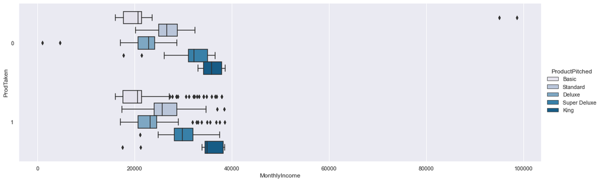

```python
sns.catplot(y='ProdTaken',x='MonthlyIncome', hue='ProductPitched',
            data=data,kind='box', aspect=3, orient="h", palette='PuBu');
```

Next, let's take a closer look at the MonthlyIncome of customers who did purchase a travel package by **differnt designations**:

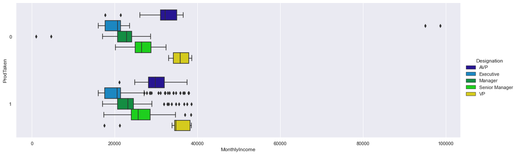

```python
sns.catplot(y='ProdTaken',x='MonthlyIncome', hue='Designation',
            data=data,kind='box', aspect=3,orient='h');
```

- By comparing the two catplots above, we could see that Executive's income matches with the group of customers who purchased or were pitched for Basic package; Manager's income matches with Deluxe-package customers; Senior Manager matches with Standard package; AVP's income matches with Super Deluxe package; and lastly VP's income matches with King package. This outcome tallies with our earlier analysis such as Basic package was only purchased by customers who are Executives.
- Besides, from the second catplot we could verify that Executives earn the least income, followed by Manager, which is in turn lesser than Senior Manager, AVP, and finally VP earns the highest income. Hence, with observation we ma rank the designation in corresponding to their respective income level:

```python
# Rank the values of Designation accordingly
data['Designation'] = pd.Categorical(data['Designation'], ordered=True,
                                     categories=['Executive', 'Manager', 'Senior Manager', 'AVP', 'VP'])
```

Now, let's take a look at the MonthlyIncome of customers by different pacakages again but with ordered Designations:

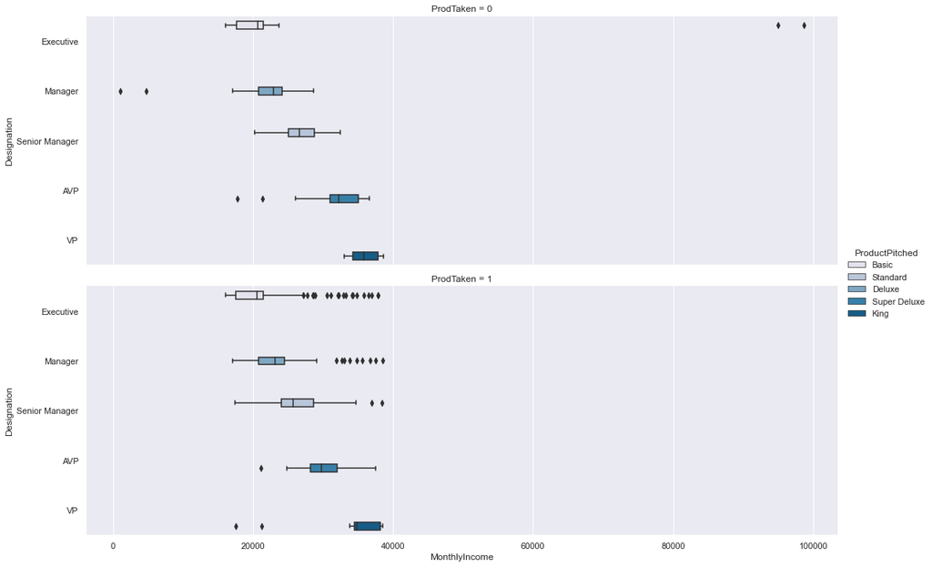

```python
sns.catplot(y='Designation',x='MonthlyIncome', hue='ProductPitched', row='ProdTaken',
            data=data,kind='box', aspect=3, orient="h", palette='PuBu');
```

- For every designation, only a boxplot is available, which further confirms that customers who purchased a particular travel package is from the same designation. And the respective income range implies the ranking of different designation.

# 4) Data Pre-Processing

- We won't treat the outliers because the models we are building are insensitive to outliers.
- scaling transformation is also unnecessary because the classifier models we are building can perform well on unscaled data.

## 4.1) Missing Values:

```python
# Review columns with missing values
data.isna().sum()
```

```
ProdTaken                     0
Age                         226
TypeofContact                25
CityTier                      0
DurationOfPitch             251
Occupation                    0
Gender                        0
NumberOfPersonVisiting        0
NumberOfFollowups            45
ProductPitched                0
PreferredPropertyStar        26
MaritalStatus                 0
NumberOfTrips               140
Passport                      0
PitchSatisfactionScore        0
OwnCar                        0
NumberOfChildrenVisiting     66
Designation                   0
MonthlyIncome               233
dtype: int64
```

```python
# Perform median imputation for numerical data
num_null_cols = ['Age', 'DurationOfPitch', 'NumberOfFollowups',
                 'PreferredPropertyStar','NumberOfTrips','NumberOfChildrenVisiting', 'MonthlyIncome']

imp_median = SimpleImputer(missing_values=np.nan, strategy='median')
data[num_null_cols] = imp_median.fit_transform(data[num_null_cols])

# Perform mode imputation for TypeofContact column
imp_mode = SimpleImputer(missing_values=np.nan, strategy='most_frequent')
data['TypeofContact'] = imp_mode.fit_transform(data[['TypeofContact']])

# Review missing values
data.isna().sum()
```

```
ProdTaken                   0
Age                         0
TypeofContact               0
CityTier                    0
DurationOfPitch             0
Occupation                  0
Gender                      0
NumberOfPersonVisiting      0
NumberOfFollowups           0
ProductPitched              0
PreferredPropertyStar       0
MaritalStatus               0
NumberOfTrips               0
Passport                    0
PitchSatisfactionScore      0
OwnCar                      0
NumberOfChildrenVisiting    0
Designation                 0
MonthlyIncome               0
dtype: int64
```

## 4.2) Treating Categorical Columns:

```python
cat_ordered = ['CityTier','ProductPitched','Designation']
cat_unordered = ['TypeofContact','Occupation', 'Gender', 'MaritalStatus']
```

```python
# Use OrdinalEncoder to encode ordered categorical variables
from sklearn.preprocessing import OrdinalEncoder
OrdinalEncoder = OrdinalEncoder()
data[cat_ordered] = OrdinalEncoder.fit_transform(data[cat_ordered])

# Use One-Hot Encoding for unordered categorical variables
data = pd.get_dummies(data, columns=cat_unordered, drop_first=True)

# view the first 5 rows of transformed data
pd.set_option('max_columns', None)
data.head()
```

|  | ProdTaken | Age | CityTier | DurationOfPitch | NumberOfPersonVisiting | NumberOfFollowups | ProductPitched | PreferredPropertyStar | NumberOfTrips | Passport | PitchSatisfactionScore | OwnCar | NumberOfChildrenVisiting | Designation | MonthlyIncome | TypeofContact_Self Enquiry | Occupation_Salaried | Occupation_Small Business | Gender_Male | MaritalStatus_Married | MaritalStatus_Single | MaritalStatus_Unmarried |
| --- | --- | --- | --- | --- | --- | --- | --- | --- | --- | --- | --- | --- | --- | --- | --- | --- | --- | --- | --- | --- | --- | --- |
| 0 | 1 | 41.0 | 2.0 | 6.0 | 3 | 3.0 | 1.0 | 3.0 | 1.0 | 1 | 2 | 1 | 0.0 | 2.0 | 20993.0 | 1 | 1 | 0 | 0 | 0 | 1 | 0 |
| 1 | 0 | 49.0 | 0.0 | 14.0 | 3 | 4.0 | 1.0 | 4.0 | 2.0 | 0 | 3 | 1 | 2.0 | 2.0 | 20130.0 | 0 | 1 | 0 | 1 | 0 | 0 | 0 |
| 2 | 1 | 37.0 | 0.0 | 8.0 | 3 | 4.0 | 0.0 | 3.0 | 7.0 | 1 | 3 | 0 | 0.0 | 1.0 | 17090.0 | 1 | 0 | 1 | 1 | 0 | 1 | 0 |
| 3 | 0 | 33.0 | 0.0 | 9.0 | 2 | 3.0 | 0.0 | 3.0 | 2.0 | 1 | 5 | 1 | 1.0 | 1.0 | 17909.0 | 0 | 1 | 0 | 0 | 0 | 0 | 0 |
| 4 | 0 | 36.0 | 0.0 | 8.0 | 2 | 3.0 | 0.0 | 4.0 | 1.0 | 0 | 5 | 1 | 0.0 | 1.0 | 18468.0 | 1 | 0 | 1 | 1 | 0 | 0 | 0 |

```python
data.shape
```

```
(4888, 22)
```

Now let's change the data type of binary variables 'ProdTaken', 'Passport' and 'OwnCar' back to its original data type for model building:

```python
binary_cols = ['ProdTaken', 'Passport', 'OwnCar']
data[binary_cols] = data[binary_cols].astype('int64')
```

# 5) Model Building

## Data preparation

```python
X = data.drop('ProdTaken', axis=1)
y = data['ProdTaken']

# Splitting data into training and test set:
X_train, X_test, y_train, y_test =train_test_split(X, y, test_size=0.3, random_state=1,stratify=y)
print(X_train.shape, X_test.shape)
```

```
(3421, 21) (1467, 21)
```

## Model evaluation criterion

#### Model can make wrong predictions as:

1. Predicting a customer would purchase the newly introduced travel package when he/she won't purchase it.
2. Predicting a customer won't purchase the newly introduced travel package when he/she would actually purchase it.

#### Which case is more important?

- If the model predicts a customer won't purchase the travel package but actually would purchase it so then the company lose the revenue that was supposed to be earned from that customer. In other words, false nagative is more impactful.

#### Which metric to optimize?

- We would want wants Recall to be maximized, greater the recall lesser the chances of false negatives.

**Let's define function to provide metric scores on train and test set and a function to show confusion matrix so that we do not have use the same code repetitively while evaluating models.**

```python
##  Function to calculate different metric scores of the model - Accuracy, Recall and Precision
def get_metrics_score(model,flag=True):
    '''
    model : classifier to predict values of X

    '''
    # defining an empty list to store train and test results
    score_list=[]

    pred_train = model.predict(X_train)
    pred_test = model.predict(X_test)

    train_acc = model.score(X_train,y_train)
    test_acc = model.score(X_test,y_test)

    train_recall = metrics.recall_score(y_train,pred_train)
    test_recall = metrics.recall_score(y_test,pred_test)

    train_precision = metrics.precision_score(y_train,pred_train)
    test_precision = metrics.precision_score(y_test,pred_test)


    score_list.extend((train_acc,test_acc,train_recall,test_recall,train_precision,test_precision))

    # If the flag is set to True then only the following print statements will be dispayed. The default value is set to True.
    if flag == True:
        print("Accuracy on training set : ",model.score(X_train,y_train))
        print("Accuracy on test set : ",model.score(X_test,y_test))
        print("Recall on training set : ",metrics.recall_score(y_train,pred_train))
        print("Recall on test set : ",metrics.recall_score(y_test,pred_test))
        print("Precision on training set : ",metrics.precision_score(y_train,pred_train))
        print("Precision on test set : ",metrics.precision_score(y_test,pred_test))

    return score_list # returning the list with train and test scores
```

```python
## Function to create confusion matrix
def make_confusion_matrix(model,y_actual,labels=[1, 0]):
    '''
    model : classifier to predict values of X
    y_actual : ground truth

    '''
    y_predict = model.predict(X_test)
    cm=metrics.confusion_matrix( y_actual, y_predict, labels=[0, 1])
    df_cm = pd.DataFrame(cm, index = [i for i in ["Actual - No","Actual - Yes"]],
                  columns = [i for i in ['Predicted - No','Predicted - Yes']])
    group_counts = ["{0:0.0f}".format(value) for value in
                cm.flatten()]
    group_percentages = ["{0:.2%}".format(value) for value in
                         cm.flatten()/np.sum(cm)]
    labels = [f"{v1}\n{v2}" for v1, v2 in
              zip(group_counts,group_percentages)]
    labels = np.asarray(labels).reshape(2,2)
    plt.figure(figsize = (10,7))
    sns.heatmap(df_cm, annot=labels,fmt='')
    plt.ylabel('True label')
    plt.xlabel('Predicted label')
```

## 5.1) Decision Tree Classifier

```
Accuracy on training set :  1.0
Accuracy on test set :  0.8670756646216768
Recall on training set :  1.0
Recall on test set :  0.6413043478260869
Precision on training set :  1.0
Precision on test set :  0.6483516483516484
```

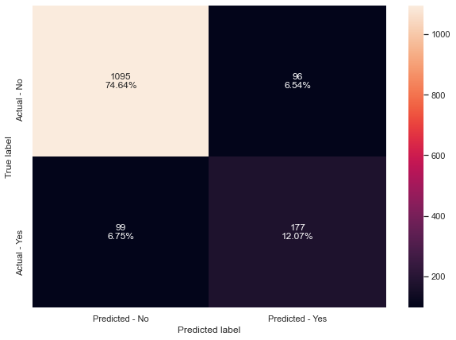

```python
#Fitting the model
d_tree = DecisionTreeClassifier(random_state=1)
d_tree.fit(X_train,y_train)

#Calculating different metrics
get_metrics_score(d_tree)

#Creating confusion matrix
make_confusion_matrix(d_tree,y_test)
```

- Decision tree is overfitting the training data.
- Let's try hyperparameter tuning and see if the model performance improves.

### Hyperparameter Tuning:

```python
#Choose the type of classifier.
dtree_estimator = DecisionTreeClassifier(class_weight={0:0.19,1:0.81},random_state=1)

# Grid of parameters to choose from
parameters = {'max_depth': np.arange(2,30),
              'min_samples_leaf': [1, 2, 5, 7, 10],
              'max_leaf_nodes' : [2, 3, 5, 10,15],
              'min_impurity_decrease': [0.0001,0.001,0.01,0.1]
             }

# Type of scoring used to compare parameter combinations
scorer = metrics.make_scorer(metrics.recall_score)

# Run the grid search
grid_obj = GridSearchCV(dtree_estimator, parameters, scoring=scorer,n_jobs=-1)
grid_obj = grid_obj.fit(X_train, y_train)

# Set the clf to the best combination of parameters
dtree_estimator = grid_obj.best_estimator_

# Fit the best algorithm to the data.
dtree_estimator.fit(X_train, y_train)
```

```
DecisionTreeClassifier(class_weight={0: 0.19, 1: 0.81}, max_depth=5,
                       max_leaf_nodes=15, min_impurity_decrease=0.0001,
                       random_state=1)
```

```
Accuracy on training set :  0.7608886290558317
Accuracy on test set :  0.7689161554192229
Recall on training set :  0.6847826086956522
Recall on test set :  0.6666666666666666
Precision on training set :  0.41761363636363635
Precision on test set :  0.42691415313225056
```

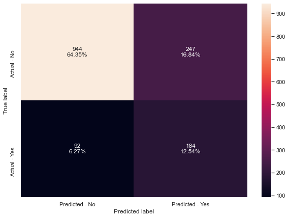

```python
get_metrics_score(dtree_estimator)

make_confusion_matrix(dtree_estimator,y_test)
```

## 5.2) Bagging Classifier

```
Accuracy on training set :  0.9944460684010523
Accuracy on test set :  0.9107021131561008
Recall on training set :  0.9704968944099379
Recall on test set :  0.6086956521739131
Precision on training set :  1.0
Precision on test set :  0.8795811518324608
```

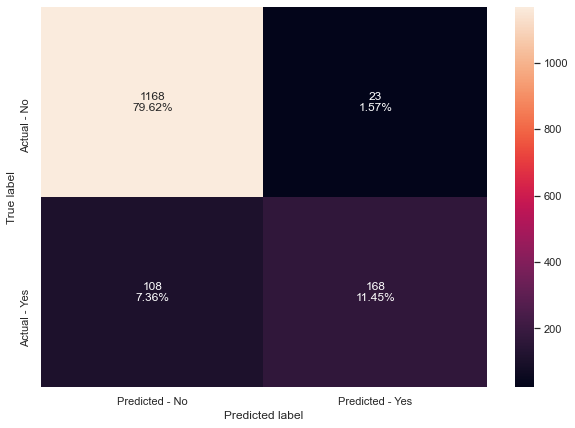

```python
#Fitting the model
bagging_classifier = BaggingClassifier(random_state=1)
bagging_classifier.fit(X_train,y_train)

#Calculating different metrics
get_metrics_score(bagging_classifier)

#Creating confusion matrix
make_confusion_matrix(bagging_classifier,y_test)
```

- From the recall score we can see that Bagging classifier is overfiiting the training data.
- Let's try hyperparameter tuning and see if the model performance improves.

```python
# Choose the type of classifier.
bagging_estimator_tuned = BaggingClassifier(random_state=1)

# Grid of parameters to choose from
parameters = {'max_samples': [0.7,0.8,0.9,1],
              'max_features': [0.7,0.8,0.9,1],
              'n_estimators' : [10,20,30,40,50],
             }

# Type of scoring used to compare parameter combinations
scorer = metrics.make_scorer(metrics.recall_score)

# Run the grid search
grid_obj = GridSearchCV(bagging_estimator_tuned, parameters, scoring=scorer,cv=5)
grid_obj = grid_obj.fit(X_train, y_train)

# Set the clf to the best combination of parameters
bagging_estimator_tuned = grid_obj.best_estimator_

# Fit the best algorithm to the data.
bagging_estimator_tuned.fit(X_train, y_train)
```

```
BaggingClassifier(max_features=0.9, max_samples=0.9, n_estimators=30,
                  random_state=1)
```

```
Accuracy on training set :  0.9991230634317451
Accuracy on test set :  0.9154737559645535
Recall on training set :  0.9953416149068323
Recall on test set :  0.5978260869565217
Precision on training set :  1.0
Precision on test set :  0.9269662921348315
```

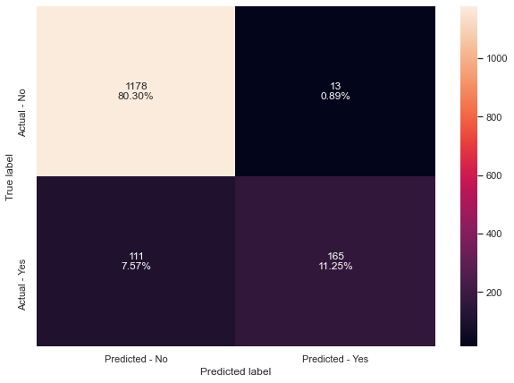

```python
#Calculating different metrics
get_metrics_score(bagging_estimator_tuned)

#Creating confusion matrix
make_confusion_matrix(bagging_estimator_tuned,y_test)
```

- There is no much difference in the model performance after hyperparameter tuning.
- Accuracy score and Precision score reflected minimal improvement on test set while its recall score became slightly worse.

## 5.3) Random Forest Classifier

```
Accuracy on training set :  1.0
Accuracy on test set :  0.9134287661895024
Recall on training set :  1.0
Recall on test set :  0.5797101449275363
Precision on training set :  1.0
Precision on test set :  0.935672514619883
```

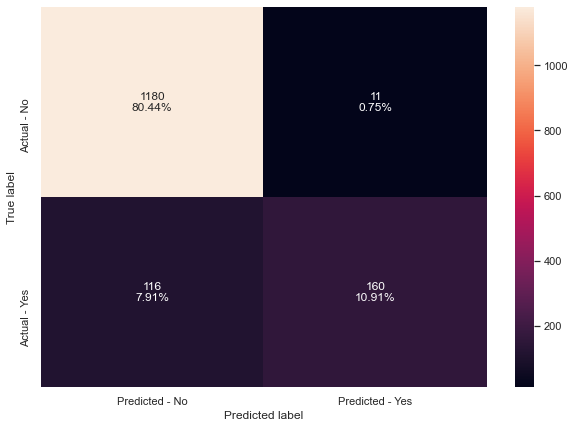

```python
#Fitting the model
rf_estimator = RandomForestClassifier(random_state=1)
rf_estimator.fit(X_train,y_train)

#Calculating different metrics
get_metrics_score(rf_estimator)

#Creating confusion matrix
make_confusion_matrix(rf_estimator,y_test)
```

- Random forest is giving lower recall score than decision trees and it is overfitting the training data.
- Let's try hyperparameter tuning and see if the model performance improves.

### Hyperparameter Tuning:

```python
# Choose the type of classifier.
rf_tuned = RandomForestClassifier(class_weight={0:0.19,1:0.81},random_state=1,oob_score=True,bootstrap=True)

parameters = {
                'max_depth': list(np.arange(5,30,5)) + [None],
                'max_features': ['sqrt','log2',None],
                'min_samples_leaf': np.arange(1,15,5),
                'min_samples_split': np.arange(2, 20, 5),
                'n_estimators': np.arange(10,110,10)}


# Type of scoring used to compare parameter combinations
scorer = metrics.make_scorer(metrics.recall_score)

# Run the grid search
grid_obj = GridSearchCV(rf_tuned, parameters, scoring=scorer, cv=5,n_jobs=-1)
grid_obj = grid_obj.fit(X_train, y_train)

# Set the clf to the best combination of parameters
rf_tuned = grid_obj.best_estimator_

# Fit the best algorithm to the data.
rf_tuned.fit(X_train, y_train)
```

```
RandomForestClassifier(class_weight={0: 0.19, 1: 0.81}, max_depth=5,
                       max_features='sqrt', min_samples_leaf=11,
                       n_estimators=80, oob_score=True, random_state=1)
```

```
Accuracy on training set :  0.8234434375913475
Accuracy on test set :  0.8118609406952966
Recall on training set :  0.7142857142857143
Recall on test set :  0.7137681159420289
Precision on training set :  0.5227272727272727
Precision on test set :  0.5
```

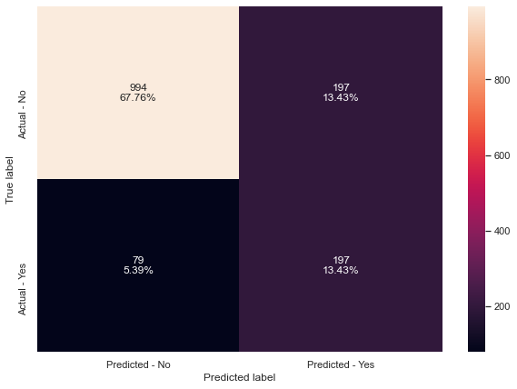

```python
#Calculating different metrics
get_metrics_score(rf_tuned)

#Creating confusion matrix
make_confusion_matrix(rf_tuned,y_test)
```

- The overfitting has reduced significantly but precision score has decreased.
- However, its overall performance is more generalised and better than earlier models.
- Let's try now try boosting models.

## 5.4) AdaBoost Classifier

```
Accuracy on training set :  0.8506284712072494
Accuracy on test set :  0.847307430129516
Recall on training set :  0.3198757763975155
Recall on test set :  0.322463768115942
Precision on training set :  0.7383512544802867
Precision on test set :  0.7063492063492064
```

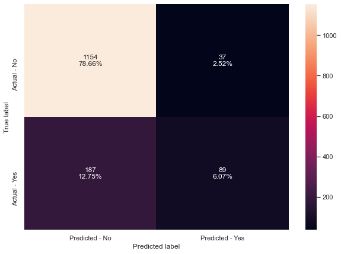

```python
#Fitting the model
ab_classifier = AdaBoostClassifier(random_state=1)
ab_classifier.fit(X_train,y_train)

#Calculating different metrics
get_metrics_score(ab_classifier)

#Creating confusion matrix
make_confusion_matrix(ab_classifier,y_test)
```

- Adaboost is giving generalized performance but the recall score is too low.

### Hyperparameter Tuning:

```python
# Choose the type of classifier.
abc_tuned = AdaBoostClassifier(random_state=1)

# Grid of parameters to choose from
parameters = {
    #Let's try different max_depth for base_estimator
    "base_estimator":[DecisionTreeClassifier(max_depth=1),DecisionTreeClassifier(max_depth=2),
                      DecisionTreeClassifier(max_depth=3)],
    "n_estimators": np.arange(10,110,10),
    "learning_rate":np.arange(0.1,2,0.1)
}

# Type of scoring used to compare parameter  combinations
scorer = metrics.make_scorer(metrics.recall_score)

# Run the grid search
grid_obj = GridSearchCV(abc_tuned, parameters, scoring=scorer,cv=5)
grid_obj = grid_obj.fit(X_train, y_train)

# Set the clf to the best combination of parameters
abc_tuned = grid_obj.best_estimator_

# Fit the best algorithm to the data.
abc_tuned.fit(X_train, y_train)
```

```
AdaBoostClassifier(base_estimator=DecisionTreeClassifier(max_depth=3),
                   n_estimators=100, random_state=1)
```

```
Accuracy on training set :  0.9900613855597779
Accuracy on test set :  0.8827539195637355
Recall on training set :  0.9642857142857143
Recall on test set :  0.5942028985507246
Precision on training set :  0.9825949367088608
Precision on test set :  0.7321428571428571
```

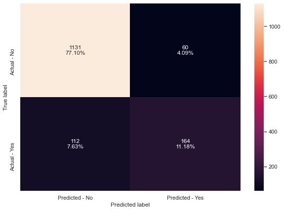

```python
#Calculating different metrics
get_metrics_score(abc_tuned)

#Creating confusion matrix
make_confusion_matrix(abc_tuned,y_test)
```

- The model performance has improved but the model has started to overfit the training data.

## 5.5) Gradient Boosting Classifier

```
Accuracy on training set :  0.8868751826951183
Accuracy on test set :  0.8650306748466258
Recall on training set :  0.453416149068323
Recall on test set :  0.38405797101449274
Precision on training set :  0.8929663608562691
Precision on test set :  0.7910447761194029
```

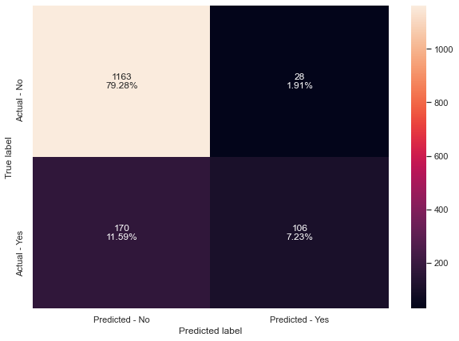

```python
#Fitting the model
gb_classifier = GradientBoostingClassifier(random_state=1)
gb_classifier.fit(X_train,y_train)

#Calculating different metrics
get_metrics_score(gb_classifier)

#Creating confusion matrix
make_confusion_matrix(gb_classifier,y_test)
```

- The gradient boosting classifier is performing better than AdaBoost Classifier but again the recall score is still too low.

### Hyperparameter Tuning:

```python
# Choose the type of classifier.
gbc_tuned = GradientBoostingClassifier(init=AdaBoostClassifier(random_state=1),random_state=1)

# Grid of parameters to choose from
parameters = {
    "n_estimators": [100,150,200,250],
    "subsample":[0.8,0.9,1],
    "max_features":[0.7,0.8,0.9,1]
}

# Type of scoring used to compare parameter combinations
scorer = metrics.make_scorer(metrics.recall_score)

# Run the grid search
grid_obj = GridSearchCV(gbc_tuned, parameters, scoring=scorer,cv=5)
grid_obj = grid_obj.fit(X_train, y_train)

# Set the clf to the best combination of parameters
gbc_tuned = grid_obj.best_estimator_

# Fit the best algorithm to the data.
gbc_tuned.fit(X_train, y_train)
```

```
GradientBoostingClassifier(init=AdaBoostClassifier(random_state=1),
                           max_features=0.8, n_estimators=250, random_state=1,
                           subsample=0.8)
```

```
Accuracy on training set :  0.9178602747734581
Accuracy on test set :  0.8786639400136332
Recall on training set :  0.6055900621118012
Recall on test set :  0.4746376811594203
Precision on training set :  0.935251798561151
Precision on test set :  0.7987804878048781
```

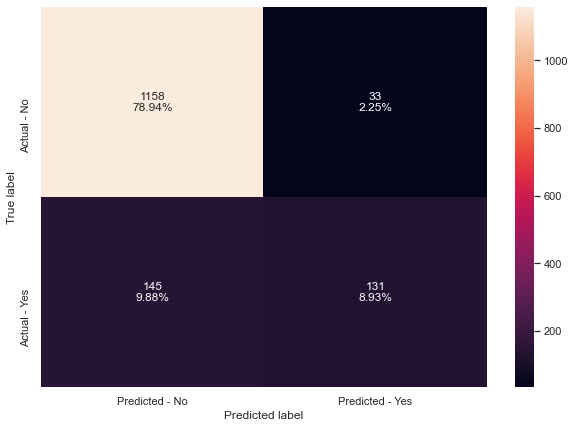

```python
#Calculating different metrics
get_metrics_score(gbc_tuned)

#Creating confusion matrix
make_confusion_matrix(gbc_tuned,y_test)
```

- The model performance has improved slightly after hyperparameter tuning.
- However the recall score is still not satisfying.

## 5.6) XGBoost Classifier

```
Accuracy on training set :  0.9997076878105817
Accuracy on test set :  0.9229720518064076
Recall on training set :  0.9984472049689441
Recall on test set :  0.6847826086956522
Precision on training set :  1.0
Precision on test set :  0.8790697674418605
```

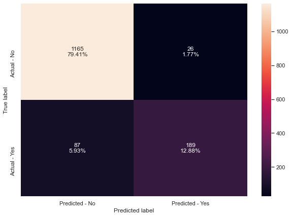

```python
#Fitting the model
xgb_classifier = XGBClassifier(random_state=1, eval_metric='logloss')
xgb_classifier.fit(X_train,y_train)

#Calculating different metrics
get_metrics_score(xgb_classifier)

#Creating confusion matrix
make_confusion_matrix(xgb_classifier,y_test)
```

- Xgboost classifier is overfitting the training data.
- Let's try hyperparameter tuning and see if the model performance improves.

### Hyperparameter Tuning:

```python
# Choose the type of classifier.
xgb_tuned = XGBClassifier(random_state=1, eval_metric='logloss')

# Grid of parameters to choose from
parameters = {
    "n_estimators": [10,30,50],
    "scale_pos_weight":[1,2,5],
    "subsample":[0.7,0.9,1],
    "learning_rate":[0.05, 0.1,0.2],
    "colsample_bytree":[0.7,0.9,1],
    "colsample_bylevel":[0.5,0.7,1]
}

# Type of scoring used to compare parameter combinations
scorer = metrics.make_scorer(metrics.recall_score)

# Run the grid search
grid_obj = GridSearchCV(xgb_tuned, parameters,scoring=scorer,cv=5)
grid_obj = grid_obj.fit(X_train, y_train)

# Set the clf to the best combination of parameters
xgb_tuned = grid_obj.best_estimator_

# Fit the best algorithm to the data.
xgb_tuned.fit(X_train, y_train)
```

```
XGBClassifier(base_score=0.5, booster='gbtree', colsample_bylevel=0.7,
              colsample_bynode=1, colsample_bytree=0.7, eval_metric='logloss',
              gamma=0, gpu_id=-1, importance_type='gain',
              interaction_constraints='', learning_rate=0.05, max_delta_step=0,
              max_depth=6, min_child_weight=1, missing=nan,
              monotone_constraints='()', n_estimators=10, n_jobs=4,
              num_parallel_tree=1, random_state=1, reg_alpha=0, reg_lambda=1,
              scale_pos_weight=5, subsample=1, tree_method='exact',
              validate_parameters=1, verbosity=None)
```

```
Accuracy on training set :  0.8304589301373867
Accuracy on test set :  0.787321063394683
Recall on training set :  0.8913043478260869
Recall on test set :  0.8333333333333334
Precision on training set :  0.5295202952029521
Precision on test set :  0.4637096774193548
```

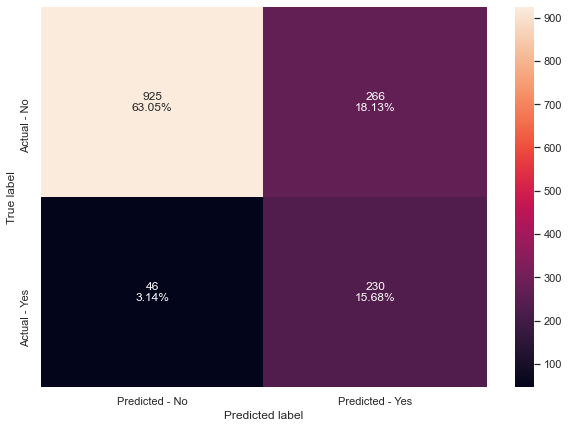

```python
#Calculating different metrics
get_metrics_score(xgb_tuned)

#Creating confusion matrix
make_confusion_matrix(xgb_tuned,y_test)
```

- The overfitting has reduced significantly.
- The confusion matrix shows that the model is slightly more capable in identifying the customers who would purchase the new travel package than identifying those who woudn't purchase it.

## 5.7) Stacking Classifier

```python
estimators = [('Decision Tree',dtree_estimator),('Random Forest',rf_tuned), ('Gradient Boosting',gbc_tuned)]

final_estimator = xgb_tuned

stacking_classifier= StackingClassifier(estimators=estimators,final_estimator=final_estimator)

stacking_classifier.fit(X_train,y_train)
```

```
StackingClassifier(estimators=[('Decision Tree',
                                DecisionTreeClassifier(class_weight={0: 0.19,
                                                                     1: 0.81},
                                                       max_depth=5,
                                                       max_leaf_nodes=15,
                                                       min_impurity_decrease=0.0001,
                                                       random_state=1)),
                               ('Random Forest',
                                RandomForestClassifier(class_weight={0: 0.19,
                                                                     1: 0.81},
                                                       max_depth=5,
                                                       max_features='sqrt',
                                                       min_samples_leaf=11,
                                                       n_estimators=80,
                                                       oob_score=True,
                                                       random_state=1)),
                               ('Gradi...
                                                 eval_metric='logloss', gamma=0,
                                                 gpu_id=-1,
                                                 importance_type='gain',
                                                 interaction_constraints='',
                                                 learning_rate=0.05,
                                                 max_delta_step=0, max_depth=6,
                                                 min_child_weight=1,
                                                 missing=nan,
                                                 monotone_constraints='()',
                                                 n_estimators=10, n_jobs=4,
                                                 num_parallel_tree=1,
                                                 random_state=1, reg_alpha=0,
                                                 reg_lambda=1,
                                                 scale_pos_weight=5,
                                                 subsample=1,
                                                 tree_method='exact',
                                                 validate_parameters=1,
                                                 verbosity=None))
```

```
Accuracy on training set :  0.8465361005553932
Accuracy on test set :  0.8152692569870484
Recall on training set :  0.8913043478260869
Recall on test set :  0.8115942028985508
Precision on training set :  0.5578231292517006
Precision on test set :  0.5056433408577878
```

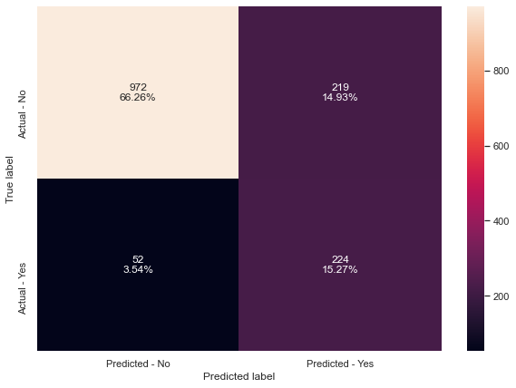

```python
#Calculating different metrics
get_metrics_score(stacking_classifier)

#Creating confusion matrix
make_confusion_matrix(stacking_classifier,y_test)
```

- Although the stacking classifier is giving similar performance as compared to XGBoost, the recall score of XGBoost is slighly better.
- The confusion matrix shows that the model is able to identify the majority of both customers who would and wouldn't purchase the new travel package, but relatively slightly better performance in identifying those who woudn't purchase it.

# 6) Comparing All Models

```python
# defining list of models
models = [d_tree, dtree_estimator, bagging_classifier,bagging_estimator_tuned, rf_estimator, rf_tuned,
          ab_classifier, abc_tuned, gb_classifier, gbc_tuned, xgb_classifier,xgb_tuned, stacking_classifier]

# defining empty lists to add train and test results
acc_train = []
acc_test = []
recall_train = []
recall_test = []
precision_train = []
precision_test = []

# looping through all the models to get the metrics score - Accuracy, Recall and Precision
for model in models:

    j = get_metrics_score(model,False)
    acc_train.append(j[0])
    acc_test.append(j[1])
    recall_train.append(j[2])
    recall_test.append(j[3])
    precision_train.append(j[4])
    precision_test.append(j[5])
```

```python
comparison_frame = pd.DataFrame({'Model':['Decision Tree','Tuned Decision Tree',
                                          'Bagging Classifier','Bagging Classifier Tuned',
                                          'Random Forest','Tuned Random Forest',
                                          'AdaBoost Classifier','Tuned AdaBoost Classifier',
                                          'Gradient Boosting Classifier', 'Tuned Gradient Boosting Classifier',
                                          'XGBoost Classifier',  'Tuned XGBoost Classifier',
                                          'Stacking Classifier'],
                                          'Train_Accuracy': acc_train,'Test_Accuracy': acc_test,
                                          'Train_Recall':recall_train,'Test_Recall':recall_test,
                                          'Train_Precision':precision_train,'Test_Precision':precision_test})

#Sorting models in decreasing order of test recall
comparison_frame.sort_values(by='Test_Recall',ascending=False)
```

|  | Model | Train_Accuracy | Test_Accuracy | Train_Recall | Test_Recall | Train_Precision | Test_Precision |
| --- | --- | --- | --- | --- | --- | --- | --- |
| 11 | Tuned XGBoost Classifier | 0.830459 | 0.787321 | 0.891304 | 0.833333 | 0.529520 | 0.463710 |
| 12 | Stacking Classifier | 0.846536 | 0.815269 | 0.891304 | 0.811594 | 0.557823 | 0.505643 |
| 5 | Tuned Random Forest | 0.823443 | 0.811861 | 0.714286 | 0.713768 | 0.522727 | 0.500000 |
| 10 | XGBoost Classifier | 0.999708 | 0.922972 | 0.998447 | 0.684783 | 1.000000 | 0.879070 |
| 1 | Tuned Decision Tree | 0.760889 | 0.768916 | 0.684783 | 0.666667 | 0.417614 | 0.426914 |
| 0 | Decision Tree | 1.000000 | 0.867076 | 1.000000 | 0.641304 | 1.000000 | 0.648352 |
| 2 | Bagging Classifier | 0.994446 | 0.910702 | 0.970497 | 0.608696 | 1.000000 | 0.879581 |
| 3 | Bagging Classifier Tuned | 0.999123 | 0.915474 | 0.995342 | 0.597826 | 1.000000 | 0.926966 |
| 7 | Tuned AdaBoost Classifier | 0.990061 | 0.882754 | 0.964286 | 0.594203 | 0.982595 | 0.732143 |
| 4 | Random Forest | 1.000000 | 0.913429 | 1.000000 | 0.579710 | 1.000000 | 0.935673 |
| 9 | Tuned Gradient Boosting Classifier | 0.917860 | 0.878664 | 0.605590 | 0.474638 | 0.935252 | 0.798780 |
| 8 | Gradient Boosting Classifier | 0.886875 | 0.865031 | 0.453416 | 0.384058 | 0.892966 | 0.791045 |
| 6 | AdaBoost Classifier | 0.850628 | 0.847307 | 0.319876 | 0.322464 | 0.738351 | 0.706349 |

- Majority of the models are either overfitting the training data or performing badly in terms of recall score.
- **Tuned XGBoost Classifier** is giving the highest recall score on the test data even though its performance is less generalised as compared with **Tuned Random Forest**.
- We shall choose Tuned XGBoost Classifier over the other because its recall score is signigicantly higher.
- Nonetheless, let's compare the important features of both models to check for common important features:

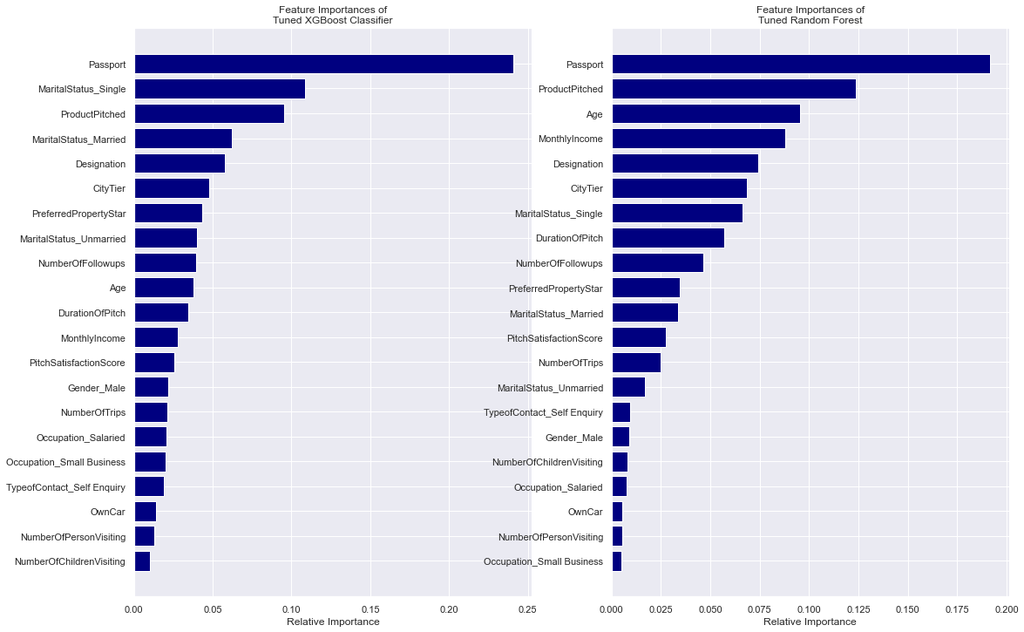

```python
feature_names = X_train.columns
importances_xgb_tuned = xgb_tuned.feature_importances_
importances_rf_tuned = rf_tuned.feature_importances_
importances = [importances_xgb_tuned , importances_rf_tuned]
model = ['Tuned XGBoost Classifier', 'Tuned Random Forest']

sns.set(rc={"figure.figsize": (18, 12)})
for i, importances_model in enumerate(importances):
    plt.subplot(1,2,i+1)
    indices = np.argsort(importances_model)

    title =  'Feature Importances of\n' + model[i]
    plt.title(title)
    plt.barh(range(len(indices)), importances_model[indices], color='navy', align='center')
    plt.yticks(range(len(indices)), [feature_names[i] for i in indices])
    plt.xlabel('Relative Importance')
plt.show()
```

- In Tuned XGBoost Classifier, the most important feature in identifying whether a customer will purchase a travel package is passport, followed by MaritalStatus and ProductPitched;
- Passport and ProductPitched are also among the top 3 important features for Tuned Random Forest, but the feature MaritalStatus isn't as important. Instead, this model takes Age as its 3rd most important feature.

# 7) Actionable Insights & Recommendations

- On the basis of our analysis, we can say that a customer who will likely purchase the newly introduced travel package has the following features in comparison to one who wouln't purchase:
  - has a passport
  - current marital status is single
  - is being pitched the targeted product
  - designation of Senior Manager
  - from Tier-3 city
  - higher number of follow-ups
- A Wellness Tourism Package, aiming at promoting a healthy lifestyle and increasing one's sense of well-being, is likely to cost more than a basic package. Hence, it might not be very afforable to an Executive. While customers who are a Senior Manager are the next group of customers with highest closure rate, we should target Senior Manager for pitching this product.
- Also from our analysis, Senior Manager are from the middle-age group (33 to 49 years old), who are more likely to value healthy lifestyle than the young energetic Executives (25 to 35 years old). This is because they have worked longer years than the young.
- Besides, the company should target Senior Manager from Tier-3 city, for higher success rate.
- One strategy the company should implement is to qualify a customer by checking whether they have a passport, currently being single, a Senior Manager, and from Tier-3 city, in order to increase number of follow-ups. This would maximise the chance of deal closure for the newly introduced Wellness Tourism Package and in the meantime reducing marketing cost by avoiding salespersons to contact customers who are less likely to purchase the package.